# Classification of fraud credit cards using Machine learning .

### In this notebook , we are going to perform the machine learning project with the goal to classify the fraud credit cards .

# Problem Statement .

#### How we will classify the fraud credit cards and actual credit cards with the help of the given dataset .

# Data

#### The data is downloaded from the kaggle :https://www.kaggle.com/code/indikab/credit-card-fraud-detection-with-99-9accuracy/data

#### creditcard.csv is the training dataset ,which contains the data of various creditcards.

## Evaluation.

#### We wil be using various classification model like Logistic Regression, Bernoulli Naïve Bayes,Random Forest Classifier,Gradient Boosting Classifier . At the end we will compare the model and the model which will give more accuraccy will be the best model.

#### We will be using confusion Matrix

```python
import pandas as pd
import numpy as np
import seaborn as sns
import matplotlib.pyplot as plt
%matplotlib inline

from sklearn.model_selection import train_test_split, KFold
```

```python
df = pd.read_csv(r'C:\Users\Admin\Desktop\data\creditcard.csv')
df.head()
```

|  | Time | V1 | V2 | V3 | V4 | V5 | V6 | V7 | V8 | V9 | ... | V21 | V22 | V23 | V24 | V25 | V26 | V27 | V28 | Amount | Class |
| --- | --- | --- | --- | --- | --- | --- | --- | --- | --- | --- | --- | --- | --- | --- | --- | --- | --- | --- | --- | --- | --- |
| 0 | 0.0 | -1.359807 | -0.072781 | 2.536347 | 1.378155 | -0.338321 | 0.462388 | 0.239599 | 0.098698 | 0.363787 | ... | -0.018307 | 0.277838 | -0.110474 | 0.066928 | 0.128539 | -0.189115 | 0.133558 | -0.021053 | 149.62 | 0 |
| 1 | 0.0 | 1.191857 | 0.266151 | 0.166480 | 0.448154 | 0.060018 | -0.082361 | -0.078803 | 0.085102 | -0.255425 | ... | -0.225775 | -0.638672 | 0.101288 | -0.339846 | 0.167170 | 0.125895 | -0.008983 | 0.014724 | 2.69 | 0 |
| 2 | 1.0 | -1.358354 | -1.340163 | 1.773209 | 0.379780 | -0.503198 | 1.800499 | 0.791461 | 0.247676 | -1.514654 | ... | 0.247998 | 0.771679 | 0.909412 | -0.689281 | -0.327642 | -0.139097 | -0.055353 | -0.059752 | 378.66 | 0 |
| 3 | 1.0 | -0.966272 | -0.185226 | 1.792993 | -0.863291 | -0.010309 | 1.247203 | 0.237609 | 0.377436 | -1.387024 | ... | -0.108300 | 0.005274 | -0.190321 | -1.175575 | 0.647376 | -0.221929 | 0.062723 | 0.061458 | 123.50 | 0 |
| 4 | 2.0 | -1.158233 | 0.877737 | 1.548718 | 0.403034 | -0.407193 | 0.095921 | 0.592941 | -0.270533 | 0.817739 | ... | -0.009431 | 0.798278 | -0.137458 | 0.141267 | -0.206010 | 0.502292 | 0.219422 | 0.215153 | 69.99 | 0 |

5 rows × 31 columns

```python
df.Class.value_counts()
```

```
0    284315
1       492
Name: Class, dtype: int64
```

```python
df.info()
```

```
<class 'pandas.core.frame.DataFrame'>
RangeIndex: 284807 entries, 0 to 284806
Data columns (total 31 columns):
 #   Column  Non-Null Count   Dtype
---  ------  --------------   -----
 0   Time    284807 non-null  float64
 1   V1      284807 non-null  float64
 2   V2      284807 non-null  float64
 3   V3      284807 non-null  float64
 4   V4      284807 non-null  float64
 5   V5      284807 non-null  float64
 6   V6      284807 non-null  float64
 7   V7      284807 non-null  float64
 8   V8      284807 non-null  float64
 9   V9      284807 non-null  float64
```

[output cut: 23 more lines]

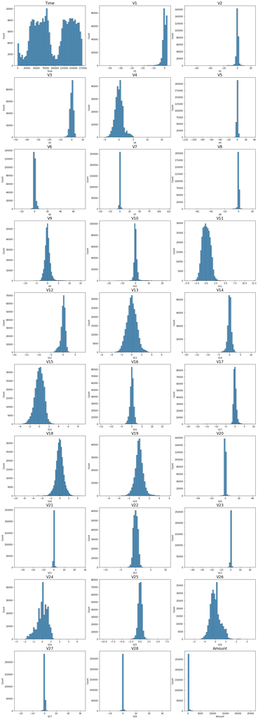

```python
normal_records = df.Class == 0
fraud_records = df.Class == 1

plt.figure(figsize=(20, 60))
for n, col in enumerate(df.drop('Class',axis=1).columns):
    plt.subplot(10,3,n+1)
    sns.histplot(df[col][df.Class == 1], bins=50)
    sns.histplot(df[col][df.Class == 0], bins=50)
    plt.title(col, fontsize=17)
plt.show()
```

```python
df[['Time','Amount','Class']].groupby('Class').describe()
```

| Class | Time count | Time mean | Time std | Time min | Time 25% | Time 50% | Time 75% | Time max | Amount count | Amount mean | Amount std | Amount min | Amount 25% | Amount 50% | Amount 75% | Amount max |
| --- | --- | --- | --- | --- | --- | --- | --- | --- | --- | --- | --- | --- | --- | --- | --- | --- |
| 0 | 284315.0 | 94838.202258 | 47484.015786 | 0.0 | 54230.0 | 84711.0 | 139333.0 | 172792.0 | 284315.0 | 88.291022 | 250.105092 | 0.0 | 5.65 | 22.00 | 77.05 | 25691.16 |
| 1 | 492.0 | 80746.806911 | 47835.365138 | 406.0 | 41241.5 | 75568.5 | 128483.0 | 170348.0 | 492.0 | 122.211321 | 256.683288 | 0.0 | 1.00 | 9.25 | 105.89 | 2125.87 |

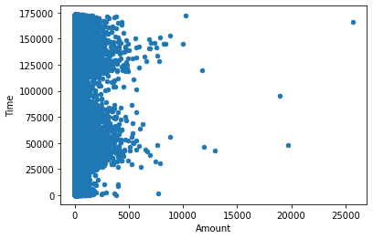

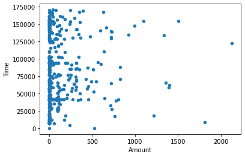

```python
df[df.Class == 0].plot.scatter('Amount','Time')
df[df.Class == 1].plot.scatter('Amount','Time')
```

```python
df[df.Amount > 10000].shape
```

```
(7, 31)
```

### There are 7 record in dataset the Ammount is greater than 10,000.00.

### with scatterplot we can see all of these transactions are belongs to non-fraudelent as well

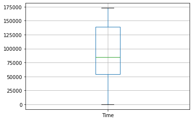

```python
df = df.drop(df[df.Amount > 10000].index, axis=0)
df.boxplot('Time')
```

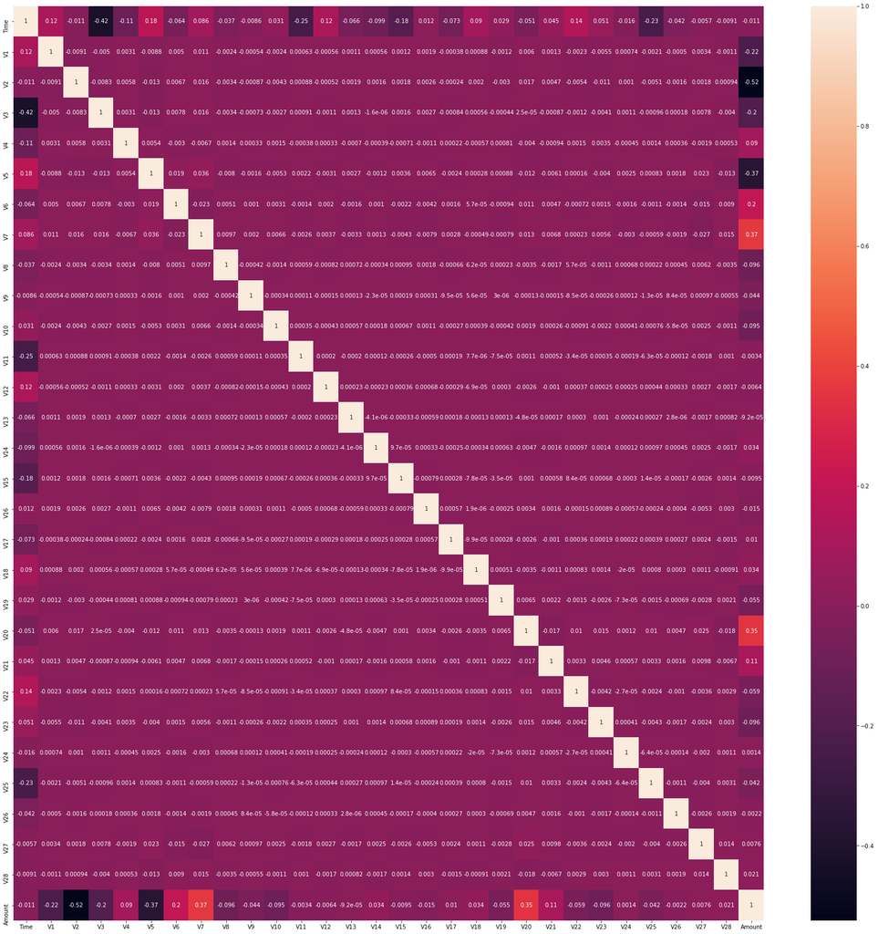

```python
x = df.drop('Class', axis=1)
y = df.Class.values
corr_matrix = x.corr()
plt.figure(figsize=(30,30))
sns.heatmap(corr_matrix, annot = True)
plt.show()
```

#### Handling Inbalance data.

```python
counts = df.Class.value_counts()
print(counts)
print(f'legimate {(counts[0] / sum(counts))*100}% and Fraudent {(counts[1] / sum(counts))*100}%')
```

```
0    284308
1       492
Name: Class, dtype: int64
legimate 99.82724719101124% and Fraudent 0.17275280898876405%
```

### Logistic Regression

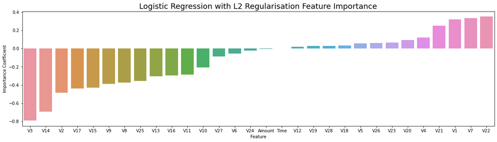

```python
from sklearn.linear_model import LogisticRegression

reg_model = LogisticRegression(max_iter=200,random_state=12, solver='liblinear')
reg_model.fit(x,y)

# coefficient matrix
coefficients = pd.concat([pd.DataFrame(x.columns),pd.DataFrame(np.transpose(reg_model.coef_))], axis = 1)
coefficients.columns = ['Feature','Importance Coefficient']
coefficients.sort_values(by='Importance Coefficient', inplace=True)

# Plotting coefficient values
plt.figure(figsize=(20,5))
sns.barplot(x='Feature', y='Importance Coefficient', data=coefficients)
plt.title("Logistic Regression with L2 Regularisation Feature Importance", fontsize=18)

plt.show()
```

### There are no sifnificant with ammount and time with class as expected. lets remove those columns.

### Cleaning the data

```python
x.drop(['Time','Amount'], axis=1, inplace=True)
```

### Summary of EDA

#### 1. Data looks clean

#### 2.No null values

#### 3. Majority of features are well distributed around mean

#### 4. There are some corereated features. but not strong enough to drop

#### 5. Dataset is highly imbalanced.

### Resampling stratergy

#### Since dataset is highly unbalanced we can use under sampling or mix of under and over sampling to increase number of samples

```python
leg_df = df[df.Class == 0]
fraud_df = df[df.Class == 1]

no_of_samples = round(leg_df.shape[0] * 0.05)
no_of_samples

from imblearn.over_sampling import RandomOverSampler
from sklearn.utils import resample

leg_df_2 = resample(leg_df, n_samples=no_of_samples, random_state=15)
# leg_df_2.describe()
df_sampled = pd.concat([leg_df_2,fraud_df],axis=0)

x_sampled = df_sampled.drop('Class', axis=1)
y_sampled = df_sampled.Class
ros = RandomOverSampler(random_state=42)

x,y = ros.fit_resample(x_sampled,y_sampled)
```

```python
y.value_counts()
```

[output not shown]

```python
x_train,x_test,y_train,y_test = train_test_split(x,y, stratify=y, random_state=12)
y_train.value_counts(), y_test.value_counts()
```

[output not shown]

### Defining Evaluation criteria

```python
columns = ['Model','accuracy score', ' Precision','Recall','f1_score']
evaluation_df = pd.DataFrame(columns=columns)
evaluation_df
```

|  | Model | accuracy score | Precision | Recall | f1_score |
| --- | --- | --- | --- | --- | --- |

```python
import sklearn.metrics as metrics

def print_results(model_name, y_test, y_pred, pred_prob=None):
    print(model_name)
    print('--------------------------------------------------------------------------')

    precision_score = metrics.precision_score(y_test, y_pred)
    recall_score = metrics.recall_score(y_test, y_pred)

    accuracy_score  = metrics.accuracy_score(y_test,y_pred)
    print(f'accuracy score :{accuracy_score}')

    f1_score = metrics.f1_score(y_test,y_pred)

    classification_report = metrics.classification_report(y_test,y_pred)
    print(classification_report)
    evaluation_df.loc[len(evaluation_df.index)] = [model_name,accuracy_score,precision_score,recall_score, f1_score]

    Plot_confusion_matrix(y_test,y_pred,model_name)

    if pred_prob is not None:
        Plot_roc_curve(y_test,pred_prob,model_name,accuracy_score)
```

### Created a common function to plot confusion matrix

```python
def Plot_confusion_matrix(y, pred, model_name):
    cm = metrics.confusion_matrix(y, pred)
    plt.clf()
    plt.imshow(cm, cmap=plt.cm.Accent)
    categoryNames = ['Non-Fraudulent','Fraudulent']
    plt.title(f'Confusion Matrix - {model_name}')
    plt.ylabel('True labels')
    plt.xlabel('Predicted labels')
    ticks = np.arange(len(categoryNames))
    plt.xticks(ticks, categoryNames, rotation=45)
    plt.yticks(ticks, categoryNames)
    s = [['TN','FP'], ['FN', 'TP']]

    for i in range(2):
        for j in range(2):
            plt.text(j,i, str(s[i][j])+" = "+str(cm[i][j]),fontsize=12)
    plt.show()
```

```python
def Plot_roc_curve(y, y_prob, model_name, score):
    plt.title(f'ROC Curve - {model_name}')
    fpr, tpr, thresholds = metrics.roc_curve(y, y_prob)
    plt.plot(fpr,tpr,label="Test, auc="+str(score))
    plt.legend(loc=4)
    plt.show()
```

### Logistic Regression

[output not shown]

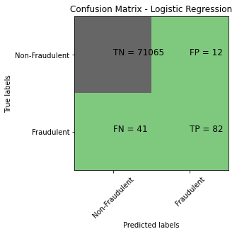

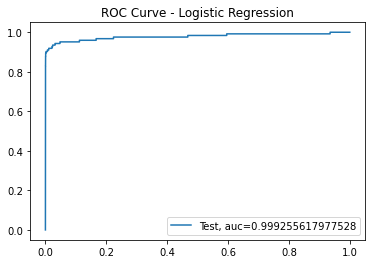

```python
lr_model = LogisticRegression(max_iter=200,random_state=12)
lr_model.fit(x_train,y_train)
pred1 = lr_model.predict(x_test)
prob1 = lr_model.predict_proba(x_test)
print_results("Logistic Regression", y_test, pred1,prob1[:,-1])
```

### Logistic Regression CV

```
Logistic Regression CV
--------------------------------------------------------------------------
accuracy score :0.9992415730337079
              precision    recall  f1-score   support

           0       1.00      1.00      1.00     71077
           1       0.89      0.64      0.75       123

    accuracy                           1.00     71200
   macro avg       0.94      0.82      0.87     71200
weighted avg       1.00      1.00      1.00     71200
```

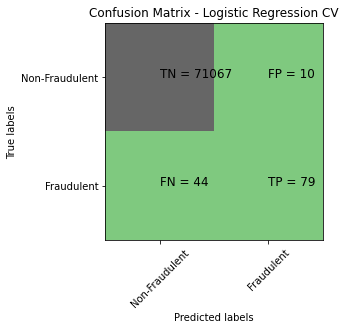

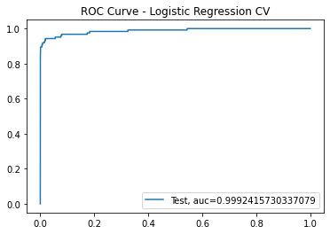

```python
from sklearn.linear_model import LogisticRegressionCV

cv_num = KFold(n_splits=10, shuffle=True, random_state=12)
lr_modelCV = LogisticRegressionCV(max_iter=200,penalty='l2',scoring='roc_auc',cv=cv_num,tol=10,random_state=12)
lr_modelCV.fit(x_train,y_train)
pred2 = lr_modelCV.predict(x_test)
prob2 = lr_modelCV.predict_proba(x_test)
print_results("Logistic Regression CV", y_test, pred2,prob2[:,-1])
```

### Bernoulli Naive Bayes Classifier

```
Bernoulli Naive Bayes
--------------------------------------------------------------------------
accuracy score :0.9991292134831461
              precision    recall  f1-score   support

           0       1.00      1.00      1.00     71077
           1       0.82      0.63      0.72       123

    accuracy                           1.00     71200
   macro avg       0.91      0.82      0.86     71200
weighted avg       1.00      1.00      1.00     71200
```

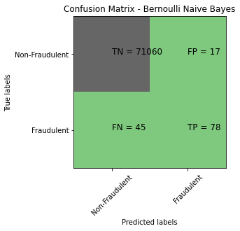

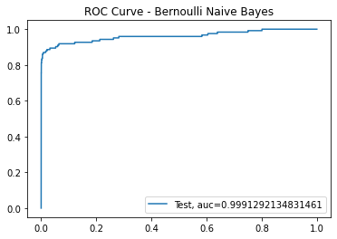

```python
from sklearn.naive_bayes import BernoulliNB
gnb_model = BernoulliNB()
gnb_model.fit(x_train,y_train)
pred3 = gnb_model.predict(x_test)
prob3 = gnb_model.predict_proba(x_test)
print_results("Bernoulli Naive Bayes", y_test, pred3,prob3[:,-1])
```

### RandomForestClassifier

```
Random Forest Classifier + gini
--------------------------------------------------------------------------
accuracy score :0.9996348314606741
              precision    recall  f1-score   support

           0       1.00      1.00      1.00     71077
           1       0.94      0.84      0.89       123

    accuracy                           1.00     71200
   macro avg       0.97      0.92      0.94     71200
weighted avg       1.00      1.00      1.00     71200
```

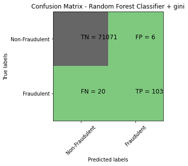

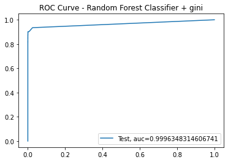

```
Random Forest Classifier + entropy
--------------------------------------------------------------------------
accuracy score :0.9996348314606741
              precision    recall  f1-score   support

           0       1.00      1.00      1.00     71077
           1       0.95      0.83      0.89       123

    accuracy                           1.00     71200
   macro avg       0.98      0.91      0.94     71200
weighted avg       1.00      1.00      1.00     71200
```

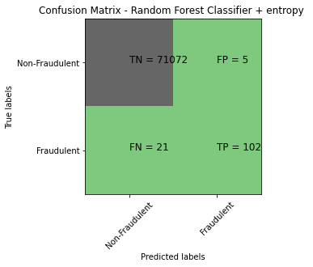

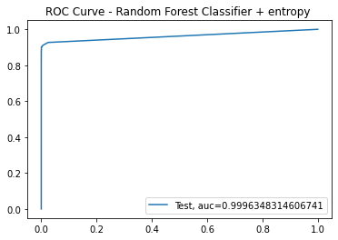

```python
from sklearn.ensemble import RandomForestClassifier

rfc_model = RandomForestClassifier(bootstrap = True,
                                max_features = 'sqrt', random_state=12)
rfc_model.fit(x_train,y_train)
pred5 = rfc_model.predict(x_test)
prob5 = rfc_model.predict_proba(x_test)
print_results("Random Forest Classifier + gini", y_test, pred5,prob5[:,-1])

rfc_model2 = RandomForestClassifier(bootstrap = True,criterion='entropy',max_features = 'sqrt', random_state=12)
rfc_model2.fit(x_train,y_train)
pred6 = rfc_model2.predict(x_test)
prob6 = rfc_model2.predict_proba(x_test)
print_results("Random Forest Classifier + entropy ", y_test, pred6,prob6[:,-1])
```

### Gradient Boosting Classifier

```
Gradient Boosting Classifier
--------------------------------------------------------------------------
accuracy score :0.9994803370786517
              precision    recall  f1-score   support

           0       1.00      1.00      1.00     71077
           1       0.95      0.74      0.83       123

    accuracy                           1.00     71200
   macro avg       0.97      0.87      0.92     71200
weighted avg       1.00      1.00      1.00     71200
```

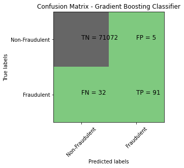

```python
from sklearn.ensemble import GradientBoostingClassifier

gbc_model = GradientBoostingClassifier()
gbc_model.fit(x_train,y_train)
pred = gbc_model.predict(x_test)
pred_prob = gbc_model.predict_proba(x_test)
print_results("Gradient Boosting Classifier", y_test, pred)
```

```python
evaluation_df
```

|  | Model | accuracy score | Precision | Recall | f1_score |
| --- | --- | --- | --- | --- | --- |
| 0 | Logistic Regression | 0.999256 | 0.872340 | 0.666667 | 0.755760 |
| 1 | Logistic Regression CV | 0.999242 | 0.887640 | 0.642276 | 0.745283 |
| 2 | Bernoulli Naive Bayes | 0.999129 | 0.821053 | 0.634146 | 0.715596 |
| 3 | Random Forest Classifier + gini | 0.999635 | 0.944954 | 0.837398 | 0.887931 |
| 4 | Random Forest Classifier + entropy | 0.999635 | 0.953271 | 0.829268 | 0.886957 |
| 5 | Gradient Boosting Classifier | 0.999480 | 0.947917 | 0.739837 | 0.831050 |